# The World Bank and climate change

Big Issues · Imperial College Business School

Ralf Martin

2 November 2026

## One group, five institutions

### “The World Bank” — lends to governments

- **IBRD** — middle-income countries, market-rate loans
- **IDA** — the poorest ~75 countries, grants and near-zero-interest credits

### The rest of the World Bank Group

- **IFC** — invests in the **private sector**: loans, equity, mobilising other investors *(where I worked)*
- **MIGA** — political-risk insurance and guarantees
- **ICSID** — investment dispute settlement

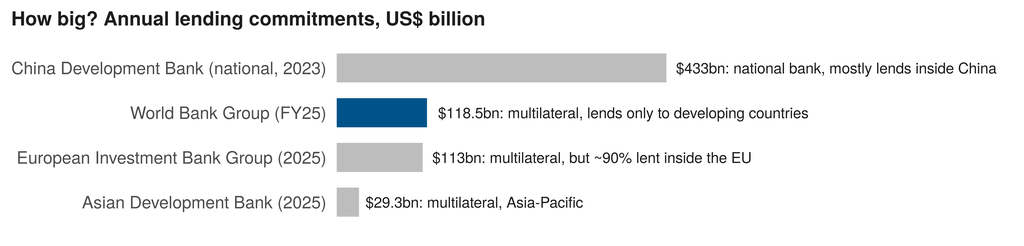

189 member countries. EIB converted from €100bn. Sources: [World Bank FY25 financial summary](https://www.worldbank.org/en/about/annual-report/financial-summary) · [EIB key figures](https://www.eib.org/en/about/key-figures/) · [ADB 2025](https://www.donorplatform.org/post/adb-annual-report-2025/) · [CDB (SOAS)](https://www.soas.ac.uk/sites/default/files/2025-03/SOAS%20DLD%20Case%20Study%20China%20Development%20Bank.pdf)

## Mission: poverty *on a livable planet*

> **“To end extreme poverty and boost shared prosperity on a livable planet.”**

> — World Bank Group mission, adopted 2023 (the [“Evolution Roadmap”](https://consultations.worldbank.org/content/dam/sites/consultations/doc/2023/WBG-Evolution-roadmap.pdf))

**Not new, though.** Climate has been part of the Bank’s official strategy since **2008** ([Strategic Framework on Development and Climate Change](https://documents1.worldbank.org/curated/en/210721468139493088/pdf/478930v20Revis1evious0record10DCCSF.pdf)), building on an **Environment Department** set up in **1987**.

#### Why climate is in it

The poor are hit first and hardest — floods, droughts, heat, crop failure.

#### Development needs energy

Hundreds of millions still lack electricity. The question is *which* energy.

#### Mainstreamed, not a silo

In FY25, **97%** of World Bank projects had a climate component<sup>1</sup> — but climate finance was **49%** of the money committed.

[^1]: A project counts if *any* part of its financing is tagged as climate finance (see next slide). The 49% is $39.2bn of $80.8bn in new IBRD + IDA commitments; the Bank does not report the climate share of disbursements.

## The largest climate financier of developing countries

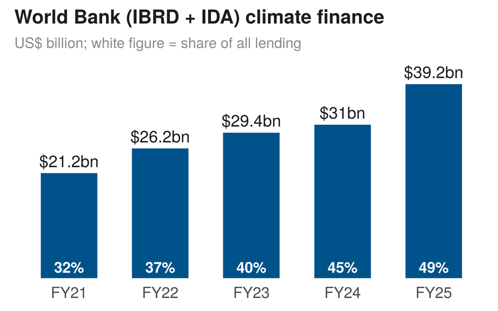

$50.8bn

Group-wide climate finance in FY25<sup>1</sup>

- IBRD $22.5bn · IDA $16.7bn
- IFC $8.1bn · MIGA $3.5bn

$190bn

over FY21–25

In the poorest (IDA) countries, **over half** goes to **adaptation**.

[^2]: “Climate finance” = the part of each project tagged as mitigation or adaptation under the joint methodology of the multilateral development banks, counted activity by activity (mitigation: activities on an agreed list, e.g. renewables; adaptation: activities addressing an identified climate vulnerability). Figures are new commitments (approvals), mostly loans to be repaid, not grants or money disbursed. Source: [World Bank FY25 Climate-Related Disclosures](https://thedocs.worldbank.org/en/doc/f8a2c887929c44d9dab187f3fc1ad293-0040012025/original/WB-FY25-Climate-Related-Disclosures.pdf)

## Where the climate money goes

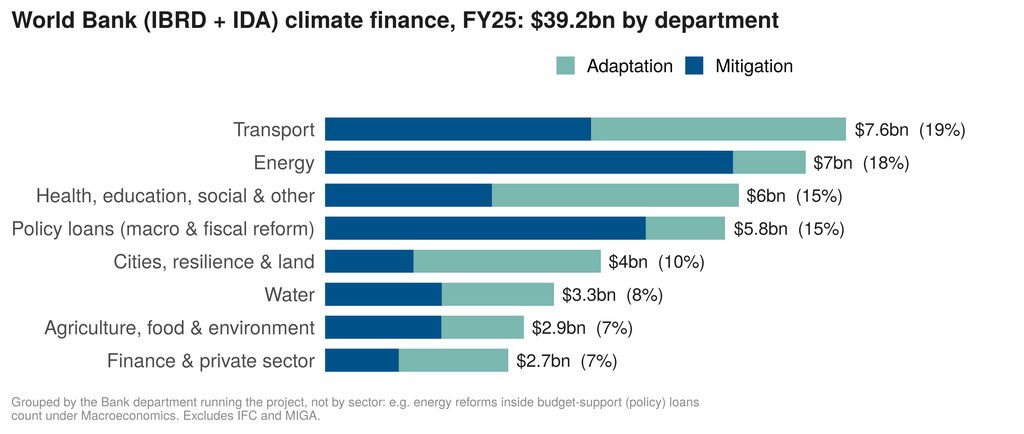

Source: [World Bank, Climate Finance 2025 — project-level data](https://thedocs.worldbank.org/en/doc/af985cf92e8b967ba707f43fb2dd9de7-0320012025/original/FY25-Project-Level-WB-CCB-data.pdf)

## A pioneer in clean power markets

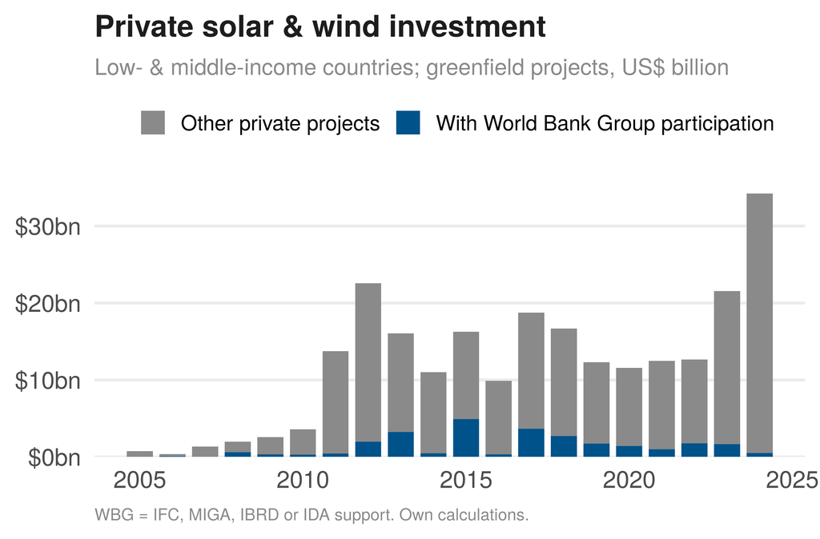

Source: [World Bank Private Participation in Infrastructure (PPI) database](https://ppi.worldbank.org)

**From ~$1bn a year in the mid-2000s to $34bn in 2024.**

WBG share of that investment:

| Period | WBG share | Any MDB |
| --- | --- | --- |
| 2005-10 | 13% | 24% |
| 2011-15 | 14% | 25% |
| 2016-20 | 14% | 28% |
| 2021-24 | 6% | 25% |

A country’s **first** private solar/wind deals were **twice as likely** to have multilateral backing as its later deals (45% vs 21%).

## My work: innovation in green technologies

**IFC Insights Report (2025): *Innovation in Green Technologies***

- Developing countries (ex China) produce **< 1%** of global green innovation…
- …but extra green R&D there has **high returns**: above average innovation in rich countries

**My hypothesis:** developing countries need *more* of their own innovation —

1. **for growth** — new technology waves (electronics in Korea and Taiwan, green tech in China) are how countries catch up
2. **for climate solutions that fit** — technologies for local climate, conditions and adaptation needs that rich-country R&D won’t prioritise

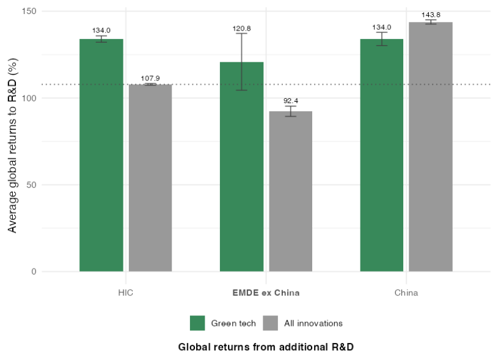

Global returns to extra R&D, multi-country patents 2013–22; dotted line = average across all innovations. [Interactive version](https://mondpanther.github.io/kevceinsights/green-technology-innovation.html) · [IFC report](https://www.ifc.org/en/insights-reports/2025/innovation-in-green-technologies)

[figure not shown]

## Why imported technology often doesn’t fit

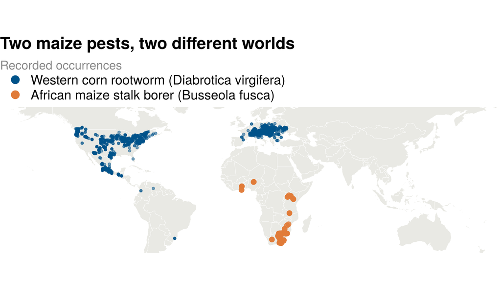

Source: GBIF.org occurrence records for [western corn rootworm](https://www.gbif.org/species/1048497) and [African maize stalk borer](https://www.gbif.org/species/1768564), accessed Nov 2026

**Maize is attacked by different pests in different places.**

- **US/Europe:** western corn rootworm (~$1bn a year in US losses) — a prime target of R&D, e.g. Bt maize
- **Sub-Saharan Africa:** African maize stalk borer destroys ~**10% of Kenya’s maize** every year — absent from the US, and Bt maize works less well against it

R&D follows rich-country problems: patents on pests present in the US outnumber those on other pests **more than 5 to 1**.

Climate change shifts pests, diseases and growing conditions — so the mismatch matters more.

Moscona & Sastry, [*Inappropriate Technology: Evidence from Global Agriculture*](https://www.nber.org/papers/w33500), NBER WP 33500

## New: who does innovation in developing countries?

#### New paper: [*Innovation partnerships for development along green value chains*](https://cep.lse.ac.uk/_NEW/PUBLICATIONS/abstract.asp?index=12648) (CEP DP 2223)

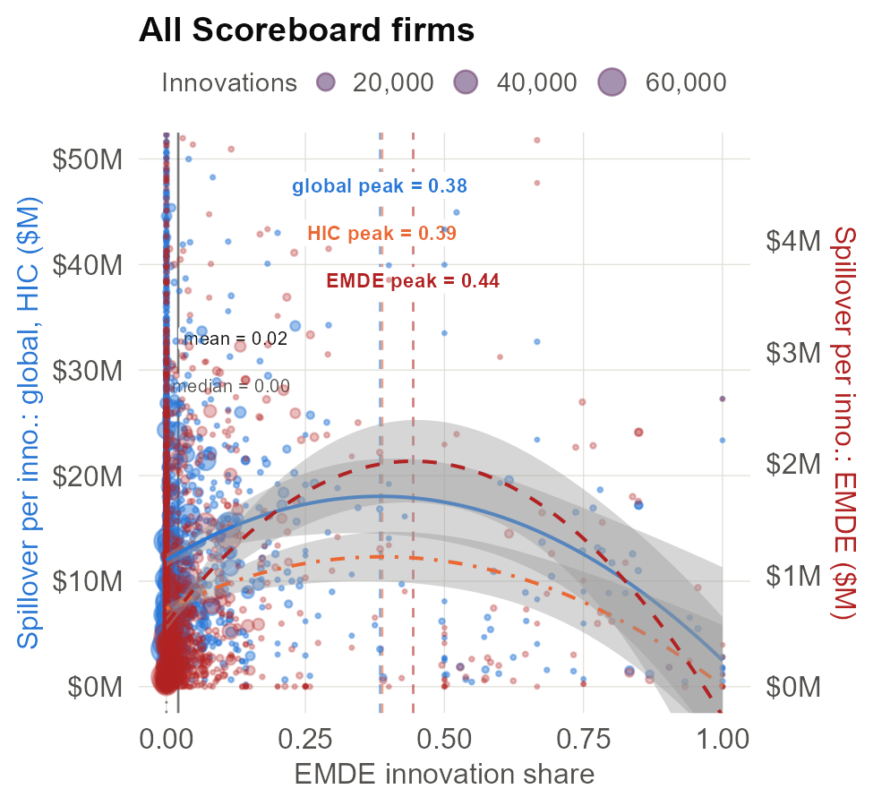

Top R&D firms create the most knowledge spillovers when **~40%** of their innovations involve developing-country inventors. The average firm is at **2%**. [Read the paper →](https://cep.lse.ac.uk/_NEW/PUBLICATIONS/abstract.asp?index=12648)

#### [EMDERLT](https://mondpanther.github.io/kevceinsights/mnc-rd-labs-map.html): ~2,000 verified R&D labs in developing countries

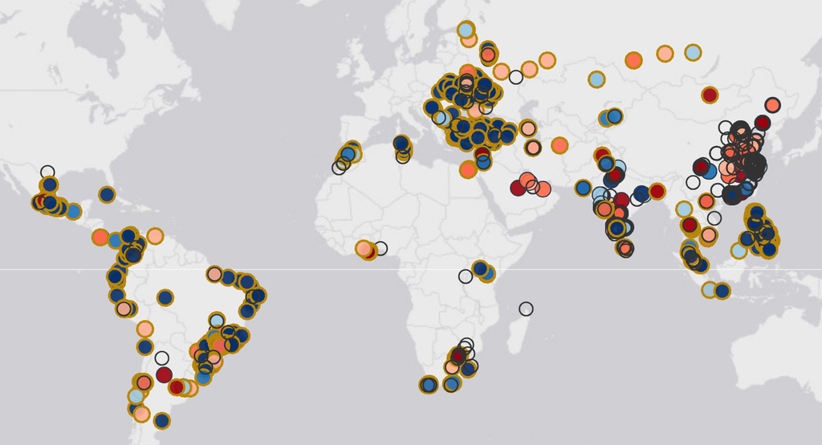

Who invents what, where — coloured by patent quality. Free to explore and download. [Open the tracker →](https://mondpanther.github.io/kevceinsights/mnc-rd-labs-map.html)

Questions?

## Appendix: biggest climate-finance projects, FY25 (1/2)

| # | Project | Country | Climate (US$m) | % of project | Adapt. / Mitig. |
| --- | --- | --- | --- | --- | --- |
| 1 | **Infrastructure modernization (policy loan, $1.5bn)** Reforms opening electricity to a competitive wholesale market and private transmission investment, private rail operators and port concessions (i… | South Africa | 1,083 | 72% | 0 / 1083 |
| 2 | **Railways extension and modernization** Rehabilitates 1,047 km of railway from Umm Qasr port via Baghdad to Mosul, plus locomotives and rolling stock, to shift freight from trucks to rail. | Iraq | 926 | 100% | 45 / 882 |
| 3 | **Irrigation modernization and water efficiency** Modernises irrigation on 72,000 ha in central Anatolia and Antalya to cut water lost from open canals; serves 50,000+ farms. | Türkiye | 818 | 100% | 410 / 408 |
| 4 | **Energy transition and climate resilience (policy loan)** Reforms to procure 1,000 MW of offshore wind, raise renewables to 42% of capacity by 2027, let consumers choose their electricity supplier, a… | Philippines | 680 | 85% | 120 / 560 |
| 5 | **Eastern ‘Middle Corridor’ railway** Builds a fully electrified 660 km line from Divriği (Sivas) to Kars near the Georgian border, replacing diesel trains on the east-west trade route to Central Asia… | Türkiye | 660 | 100% | 165 / 495 |

Source: [World Bank, Climate Finance 2025 — project-level data](https://thedocs.worldbank.org/en/doc/af985cf92e8b967ba707f43fb2dd9de7-0320012025/original/FY25-Project-Level-WB-CCB-data.pdf) (IBRD + IDA only); descriptions from World Bank project announcements.

## Appendix: biggest climate-finance projects, FY25 (2/2)

| # | Project | Country | Climate (US$m) | % of project | Adapt. / Mitig. |
| --- | --- | --- | --- | --- | --- |
| 6 | **Productive and sustainable investment (policy loan, $1.5bn)** Deepens the financial sector (incl. accounting for climate and disaster risk), eases local-content rules that hold back renewable procur… | Indonesia | 619 | 41% | 366 / 253 |
| 7 | **Least-cost electrification (ISLE-2)** Adds 540 MW of solar and wind and brings electricity to 3.5 million people in Kalimantan and Sumatra; expected to cut generation costs by 8%+. | Indonesia | 528 | 88% | 46 / 483 |
| 8 | **Transition to a sustainable electricity sector** Funds electricity-tariff subsidies for low-income households and better targeting through the energy-subsidy registry (RASE). | Argentina | 500 | 100% | 0 / 500 |
| 9 | **Public transport sustainability and equity** Funds a 55% public-transport fare discount for pensioners and benefit recipients in 61 cities, and discounted transfers in an integrated ticket system. | Argentina | 500 | 100% | 0 / 500 |
| 10 | **Productivity, sustainability and inclusion (policy loan, $1bn)** Tax and social-assistance reforms; the climate part is the Ecological Transformation Plan and restoring Bolsa Verde payments for fore… | Brazil | 500 | 50% | 130 / 370 |

The top 10 make up **17%** of the $39.2bn across 432 projects. Four are **budget-support (policy) loans**, which account for 23% of all climate finance: the “climate” part is the share of reforms judged climate-relevant. Note that both Argentine projects are tagged **100% mitigation** although they mainly fund targeted subsidies.

Policy loans identified from project titles.